# Calaveras River

Sadie Gill, Mark Tompkins, Erin Cain

June 17, 2019

## Future Data Improvements

None planned

## Instream Spawning and Rearing Habitat

**Data Source:** [FISHBIO Environmental and Thomas R. Payne & Associates 2009](https://s3-us-west-2.amazonaws.com/cvpiahabitat-r-package/cvpia-sit-model-inputs/FishBio_Payne2009_CalaverasInstreamFlowStudy.pdf) (pgs. 18-19)

No habitat modeling is available for Chinook on the Calaveras River. Instream spawning and rearing habitat for Steelhead in the Calaveras River is used as a proxy for Chinook. This data is based on an instream flow study conducted by FISHBIO and Thomas Payne for the Stockton East Water District. They used a Physical Habitat Simulation model on four reaches to find a relationship between streamflow and suitable Steelhead habitat. Graphs showing the original data are on pgs. 18-19 of the study report linked above. The Steelhead spawning habitat data from Mark Gard was cross-referenced with the original FISHBIO data and amended to include all of the original data in the FISHBIO reports by adding values digitized from the flow : area curves in the using https://automeris.io/WebPlotDigitizer/. Values from the four reaches were compiled into a spreadsheet (see ‘~/cvpiaHabitat/data-raw/Calaveras_all_reaches.xlsx’) and then the data from each reach was weighted by the length of the reach to find the weighted average of the Steelhead spawning and rearing WUA in Calaveras River. This approach was developed in coordination with Mark Gard from the U.S. Fish and Wildlife Service. We used cells A16:D26 with a reach length of 18,282 ft, A30:D40 with a reach length of 25,438 ft, and A43:D43 with a reach length of 27,867 ft.

### Combine Spawning and Rearing Data

The instream spawning and rearing habitat data described above for Steelhead (ST) is combined for use in the DSM in the following format. Units are in square feet per 1000 feet.

| flow_cfs | ST_spawn_wua | ST_fry_wua | ST_juv_wua | watershed |
| --- | --- | --- | --- | --- |
| 12 | 1737.744 | 4792.500 | 4176.620 | Calaveras River |
| 35 | 5138.939 | 4084.211 | 5802.634 | Calaveras River |
| 50 | 6613.834 | 3530.341 | 6414.535 | Calaveras River |
| 100 | 8289.293 | 3045.913 | 7328.036 | Calaveras River |
| 150 | 7930.819 | 2727.510 | 7273.727 | Calaveras River |

*…with 5 more rows.*

### Spawning WUA

The instream spawning habitat weighted usable areas for Steelhead in the Calaveras River.

#### Spawning WUA Plot

The following plot shows the weighted usable spawning area in square feet per thousand feet of river for Steelhead. These area per length rates are multiplied by the total spawning reach length mapped by the SIT.

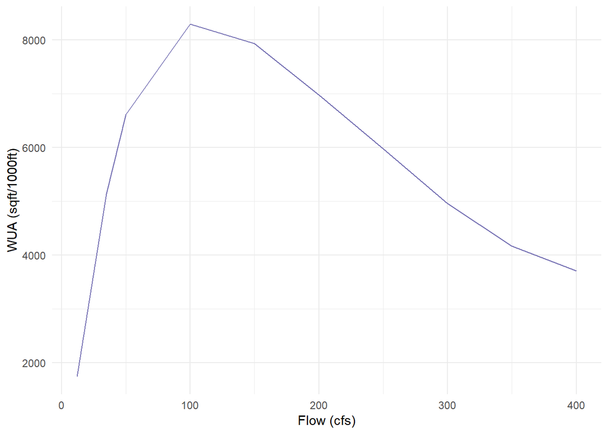

### Rearing WUA

The fry and juvenile instream rearing habitat weighted usable areas for Steelhead in the Calaveras River.

#### Rearing WUA Plot

The following plot shows the weighted usable rearing area in square feet per thousand feet of river for Steelhead fry and juvenile. These rates are multiplied by the total rearing reach length mapped by the SIT.

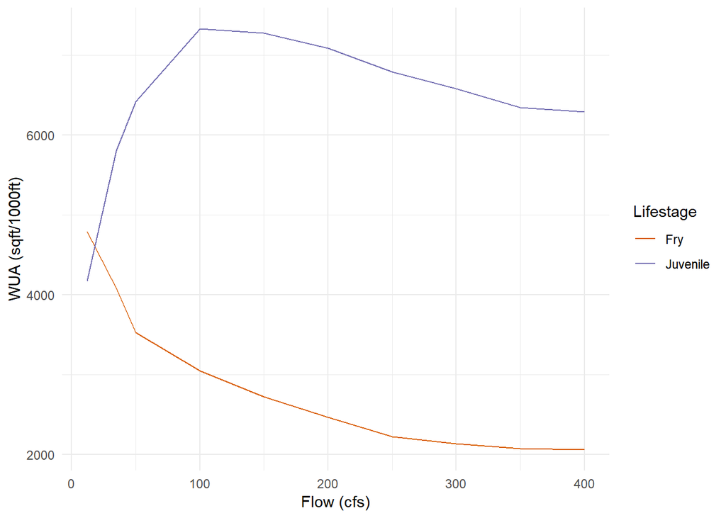